# Home Page

Author

Shawn Xu

Player Rank Analysis Final Project

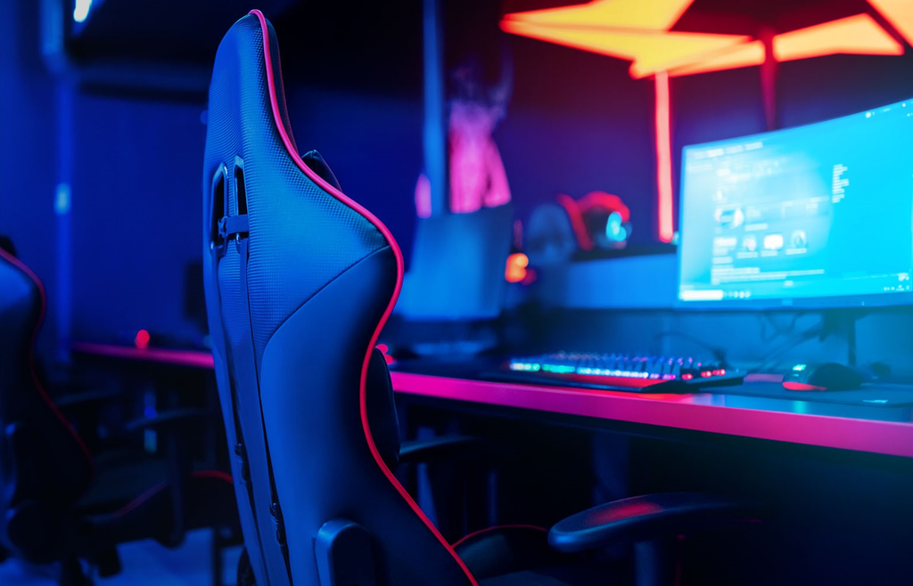

Image [Source](https://www.mnp.ca/en/insights/directory/a-day-in-the-life-of-an-esports-gamer)

In this website I will go through my project of investigating how certain players’ skill rating are determined based on in-game match data. Due to the limited amount of available player data for competitive video games, I will only examine the mainstream competitive video game: *League of Legends*.

### Project Organization

##### Introduction:

For the introduction I wanted to give some contextual information about me as well as the idea that I had for this Data Science project. This section contains in intro about me, an intro about my project, the data that I used, and the code that I made.

- [About Me](https://sxu.georgetown.domains/5000-website/_site/about_me/about_me.html)
- [Code](https://sxu.georgetown.domains/5000-website/_site/code.html)
- [Data](https://sxu.georgetown.domains/5000-website/_site/data.html)
- [Introduction](https://sxu.georgetown.domains/5000-website/_site/introduction.html)

##### Data Preparation:

For the Data Preparation section, I worked on retrieving textual and record data from the Riot API. More information can be found in the following tabs.

- [Data Gathering](https://sxu.georgetown.domains/5000-website/_site/data_gathering.html)
- [Data Cleaning](https://sxu.georgetown.domains/5000-website/_site/data_cleaning.html)
- [Data Exploration](https://sxu.georgetown.domains/5000-website/_site/eda.html)

##### Techniques:

Here lists some of techniques that I used on my retrieved data. Namely, I used Naive Bayes classification, Dimensionality Reduction, Clustering, and some Decision Tree classification techniques.

- [Naive Bayes](https://sxu.georgetown.domains/5000-website/_site/naive_bayes.html)
- [Dimensionality Reduction](https://sxu.georgetown.domains/5000-website/_site/dim_red.html)
- [Clustering](https://sxu.georgetown.domains/5000-website/_site/clustering.html)
- [Decision Trees](https://sxu.georgetown.domains/5000-website/_site/decision_tree.html)

##### Conclusion:

A small concluding segment where I talk about my findings and how it relates back to my project idea.

- [Conclusions](https://sxu.georgetown.domains/5000-website/_site/conclusion.html)